# 04 — Vocabulaire : adapte-t-il son discours au pays et au public ?

Analyses lexicales **transparentes** (on compte des mots définis à l'avance, chaque résultat est vérifiable) :

1. Un tableau de bord de 16 thèmes définis par des listes de mots anglais (`LEXIQUE` dans `outils/analyse_corpus.py`), comparés par continent, par public et par année.
2. Les mots **caractéristiques** de chaque continent et de chaque public : log-odds avec a priori de Dirichlet (Monroe et al., 2008), plus fiable qu'une simple fréquence car corrigé pour les mots rares.
3. Les références : papes, saints, concile, grands textes du pontificat.
4. Le style : longueur des phrases selon le public.

Toutes les fréquences sont des **taux pour 10 000 mots**. Les conférences de presse en vol sont exclues du corpus (`acquisition/preparer_corpus.py`).

```python
import sys, re
from pathlib import Path
ROOT = next(p for p in [Path.cwd(), *Path.cwd().parents] if (p / "outils" / "analyse_corpus.py").exists())
sys.path.insert(0, str(ROOT / "outils"))
import numpy as np
import pandas as pd
import matplotlib.pyplot as plt
from IPython.display import display, HTML
import analyse_corpus as ac

cmap = ac.style()
ac.RESULTATS.mkdir(exist_ok=True)
pd.set_option("display.max_colwidth", 110)
MOIS = ["janv.", "févr.", "mars", "avr.", "mai", "juin", "juil.", "août", "sept.", "oct.", "nov.", "déc."]
df = ac.charger()
df = df.loc[~df["en_vol"] & df["n_mots"].gt(0)].reset_index(drop=True)
df["annee"] = df["annee"].astype(int)
print(f"{len(df)} discours, {df['n_mots'].sum():,} mots.".replace(",", " "))

def tableau_de_bord(groupe, ordre_cols, titre, fichier=None):
    taux = ac.taux_lexique(df, groupe).T
    taux = taux[[c for c in ordre_cols if c in taux.columns]]
    lignes = taux.mean(axis=1).sort_values(ascending=False).index
    taux = taux.loc[lignes]
    norm = taux.div(taux.max(axis=1), axis=0)
    fig, ax = plt.subplots(figsize=(1.05 * taux.shape[1] + 5, 8))
    ac.carte_chaleur(ax, taux, cmap, fmt="{:.1f}", couleurs=norm, vmin=0, vmax=1, seuil=.65)
    n = df[groupe].astype(str).value_counts()
    ax.set_xticks(range(taux.shape[1]), [str(c).replace(", ", ",\n", 1) + f"\n(n={n.get(str(c), 0)})"
                                         for c in taux.columns], fontsize=8.5)
    ax.set_title(titre)
    fig.tight_layout()
    if fichier:
        fig.savefig(ac.RESULTATS / fichier, dpi=160, bbox_inches="tight")
    plt.show()
    return taux
```

```
342 discours  543 217 mots.
```

## Selon le continent

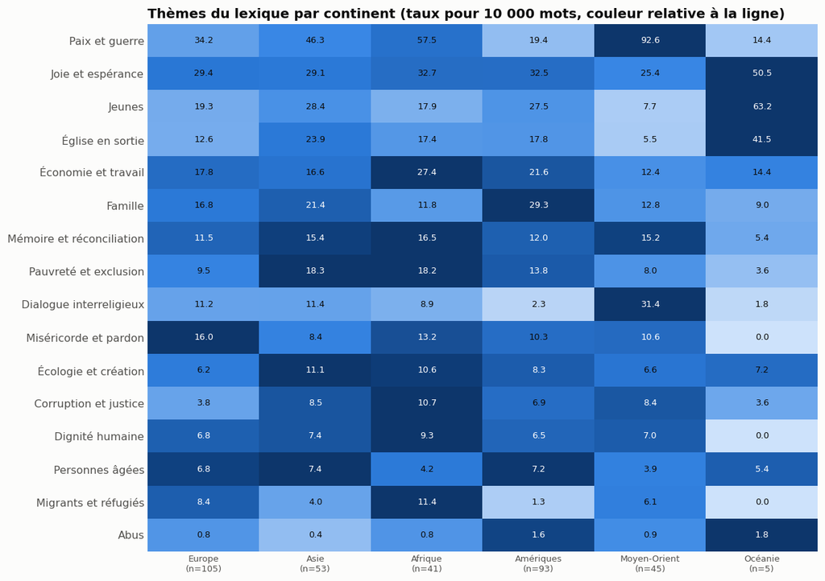

```python
t_cont = tableau_de_bord("continent", ac.ORDRE_CONTINENTS,
                         "Thèmes du lexique par continent (taux pour 10 000 mots, couleur relative à la ligne)",
                         "04_lexique_continents.png")
t_cont.to_csv(ac.RESULTATS / "04_lexique_continents.csv", encoding="utf-8-sig")
```

## Selon le public

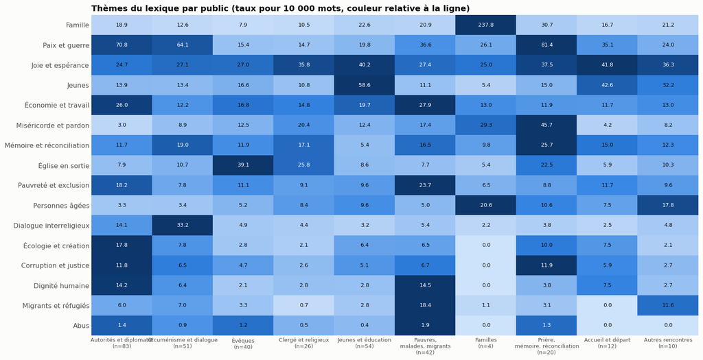

```python
t_pub = tableau_de_bord("public", ac.ORDRE_PUBLICS,
                        "Thèmes du lexique par public (taux pour 10 000 mots, couleur relative à la ligne)",
                        "04_lexique_publics.png")
```

## Selon l'année

Chaque année regroupe peu de voyages : une variation peut venir des pays visités (par exemple le Canada et les pensionnats autochtones en 2022, ou la COP28 en 2023).

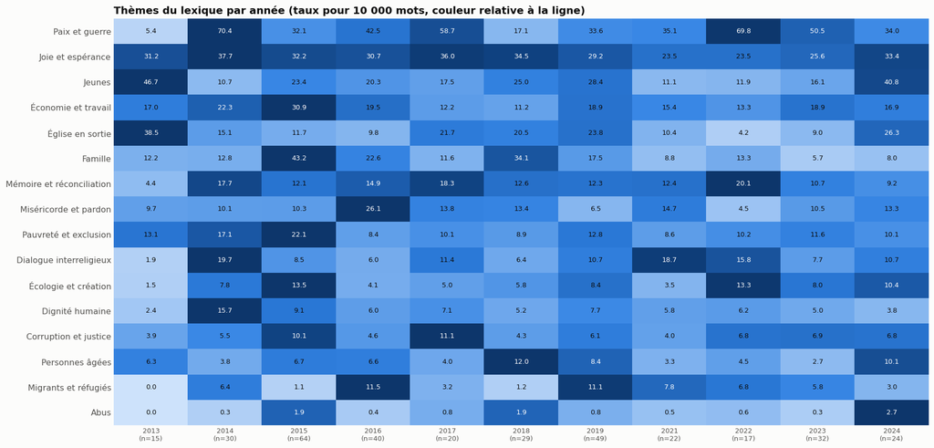

```python
t_an = tableau_de_bord("annee", sorted(df["annee"].unique()),
                       "Thèmes du lexique par année (taux pour 10 000 mots, couleur relative à la ligne)")
```

## Les mots caractéristiques de chaque continent

Pour chaque continent, les mots les plus sur-représentés par rapport aux autres (score z du log-odds ; au-delà de ~2, la différence dépasse ce qu'expliquerait le hasard). Les noms propres de lieux ressortent naturellement ; les autres mots montrent comment le discours s'adapte.

```python
from sklearn.feature_extraction.text import CountVectorizer
cv = CountVectorizer(analyzer=lambda t: [m for m in ac.mots(t) if len(m) > 2 and m not in ac.STOPWORDS], min_df=3)
C = cv.fit_transform(df["text"])
vocab = cv.get_feature_names_out()
total = np.asarray(C.sum(axis=0)).ravel().astype(float)
prior = total / total.sum() * 300

def caracteristiques(masque, n=12):
    a = np.asarray(C[masque.to_numpy()].sum(axis=0)).ravel().astype(float)
    z = ac.log_odds(a, total - a, prior)
    o = np.argsort(z)
    return pd.Series(z[o[::-1][:n]], vocab[o[::-1][:n]]), pd.Series(z[o[:n]], vocab[o[:n]])

conts = [c for c in ac.ORDRE_CONTINENTS if (df["continent"] == c).sum() >= 10]
display(pd.DataFrame({c: [f"{m} ({z:.1f})" for m, z in caracteristiques(df["continent"].eq(c))[0].items()]
                      for c in conts}).style.set_properties(**{"font-size": "11.5px"}))
```

|  | Europe | Asie | Afrique | Amériques | Moyen-Orient |
| --- | --- | --- | --- | --- | --- |
| 0 | europe (12.8) | fragrance (8.4) | africa (9.5) | latin (8.5) | peace (14.4) |
| 1 | european (8.2) | harmony (7.6) | violence (9.0) | america (8.0) | egypt (9.5) |
| 2 | roots (7.9) | asia (7.5) | moses (9.0) | family (7.7) | east (9.0) |
| 3 | sea (7.7) | religious (6.5) | hands (8.7) | jesus (7.0) | abraham (8.6) |
| 4 | bridge (6.4) | respect (6.4) | country (8.2) | indigenous (6.8) | unity (8.0) |
| 5 | parish (5.2) | religions (6.0) | republic (7.6) | families (6.8) | holiness (8.0) |
| 6 | bread (5.1) | nuclear (5.9) | african (7.5) | youth (5.9) | violence (7.3) |
| 7 | union (4.9) | spiritual (5.7) | corruption (7.0) | aparecida (5.9) | middle (7.3) |
| 8 | island (4.7) | poor (5.5) | shepherd (6.8) | pastor (5.5) | religions (7.2) |
| 9 | adventure (4.7) | healing (5.4) | south (6.1) | peoples (5.4) | fraternity (7.2) |
| 10 | tenderness (4.6) | bullying (5.3) | central (5.9) | face (5.4) | christians (7.1) |
| 11 | greek (4.6) | missionaries (5.3) | sudan (5.9) | native (5.4) | iraq (7.0) |

### Zoom : un groupe contre tous les autres

Bleu : mots sur-représentés dans le groupe ; rouge : sous-représentés. Modifier `COLONNE` et `VALEUR`.

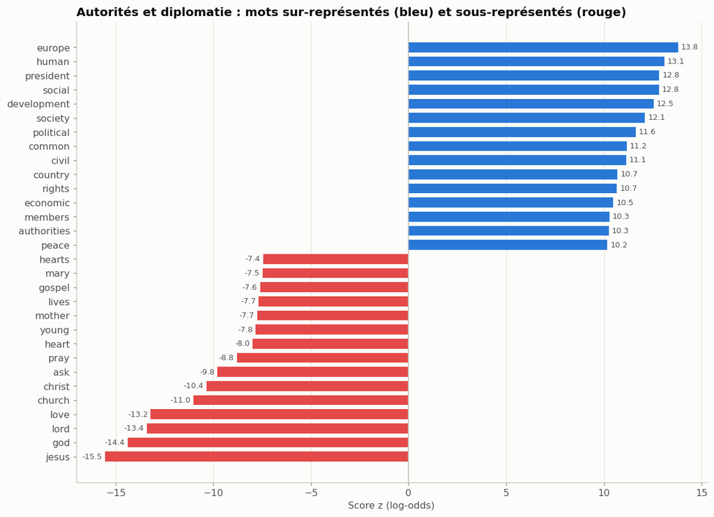

```python
COLONNE, VALEUR = "public", "Autorités et diplomatie"
plus, moins = caracteristiques(df[COLONNE].astype(str).eq(VALEUR), 15)
s = pd.concat([moins, plus.iloc[::-1]])
fig, ax = plt.subplots(figsize=(11, 8))
ax.barh(s.index, s.values, color=[ac.SERIES[0] if v > 0 else ac.SERIES[7] for v in s.values], height=.7)
ax.axvline(0, color=ac.AXE, linewidth=1)
for i, v in enumerate(s.values):
    ax.text(v + (.15 if v > 0 else -.15), i, f"{v:.1f}", va="center", ha="left" if v > 0 else "right",
            fontsize=8.5, color=ac.ENCRE_2)
ax.grid(axis="y", visible=False)
ax.set(xlabel="Score z (log-odds)", title=f"{VALEUR} : mots sur-représentés (bleu) et sous-représentés (rouge)")
fig.tight_layout(); plt.show()
```

## Le vocabulaire de chaque public

```python
pubs = [p for p in ac.ORDRE_PUBLICS if (df["public"] == p).sum() >= 10]
display(pd.DataFrame({p: [f"{m} ({z:.1f})" for m, z in caracteristiques(df["public"].astype(str).eq(p))[0].items()]
                      for p in pubs}).style.set_properties(**{"font-size": "11.5px"}))
```

|  | Autorités et diplomatie | Œcuménisme et dialogue | Évêques | Clergé et religieux | Jeunes et éducation | Pauvres, malades, migrants | Prière, mémoire, réconciliation | Accueil et départ | Autres rencontres |
| --- | --- | --- | --- | --- | --- | --- | --- | --- | --- |
| 0 | europe (13.8) | unity (12.5) | church (21.1) | consecrated (14.7) | young (24.3) | migrants (8.7) | mercy (11.0) | president (9.4) | mediterranean (12.4) |
| 1 | human (13.1) | christians (12.4) | priests (15.8) | lord (11.4) | jesus (18.2) | peoples (8.6) | nuclear (8.5) | days (7.9) | volunteers (9.5) |
| 2 | president (12.8) | communion (11.4) | pastoral (14.3) | jesus (10.8) | cross (11.4) | pain (8.3) | lady (8.5) | cuba (7.5) | sea (9.5) |
| 3 | social (12.8) | holiness (9.5) | gospel (13.0) | joy (9.8) | university (11.1) | dignity (7.0) | weapons (8.1) | sri (7.0) | marseille (8.0) |
| 4 | development (12.5) | peace (9.4) | bishops (12.5) | priests (9.2) | love (10.4) | change (6.8) | mary (7.7) | cuban (6.5) | mess (7.2) |
| 5 | society (12.1) | ecumenical (9.2) | bishop (12.1) | god (8.5) | ask (10.3) | children (6.7) | victims (7.7) | bolivia (6.4) | port (6.9) |
| 6 | political (11.6) | orthodox (9.0) | mission (11.5) | seminarians (8.4) | answer (10.0) | native (6.6) | love (7.6) | lanka (6.3) | bolivia (6.7) |
| 7 | common (11.2) | churches (8.8) | closeness (10.7) | forget (7.6) | life (10.0) | charity (6.3) | sri (6.9) | brazil (6.3) | days (6.2) |
| 8 | civil (11.1) | abraham (8.7) | missionary (10.1) | remembrance (7.6) | question (9.5) | economy (6.2) | marriage (6.9) | visit (6.2) | forwards (6.1) |
| 9 | country (10.7) | religions (8.5) | ministry (9.7) | peter (7.5) | youth (8.5) | poor (6.1) | mother (5.8) | land (6.1) | elizabeth (5.8) |
| 10 | rights (10.7) | dialogue (8.5) | pastors (9.7) | witnesses (7.4) | going (8.5) | faces (6.0) | saint (5.8) | israel (5.9) | wrote (5.7) |
| 11 | economic (10.5) | journey (8.2) | shepherd (9.6) | serve (7.4) | feel (8.5) | samaritan (5.9) | everyday (5.7) | miss (5.9) | generosity (5.7) |

## Les références

Part des discours qui mentionnent chaque référence, au total et par continent. Les textes du pontificat (Evangelii gaudium 2013, Laudato si' 2015, Amoris laetitia 2016, Fratelli tutti 2020, Document d'Abou Dhabi 2019) n'apparaissent qu'après leur publication.

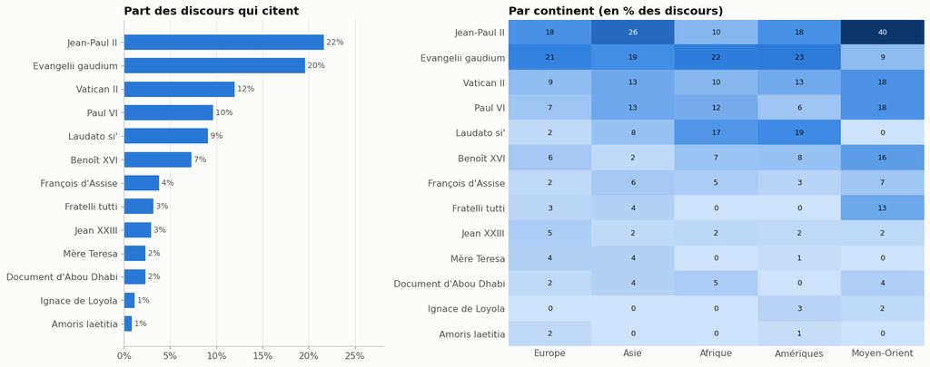

```python
refs = pd.DataFrame({nom: df["text"].str.contains(motif, regex=True) for nom, motif in ac.REFERENCES.items()})
total_ref = refs.mean().sort_values()
par_cont = refs.groupby(df["continent"], observed=True).mean().T.loc[total_ref.index[::-1], conts]
fig, axes = plt.subplots(1, 2, figsize=(15, 6), gridspec_kw={"width_ratios": [1, 1.6]})
axes[0].barh(total_ref.index, total_ref.values, color=ac.SERIES[0], height=.65)
for i, v in enumerate(total_ref.values):
    axes[0].text(v, i, f" {v:.0%}", va="center", fontsize=9, color=ac.ENCRE_2)
axes[0].xaxis.set_major_formatter(lambda v, _: f"{v:.0%}")
axes[0].grid(axis="y", visible=False)
axes[0].set(title="Part des discours qui citent", xlim=(0, total_ref.max() * 1.3))
im = ac.carte_chaleur(axes[1], par_cont * 100, cmap, fmt="{:.0f}")
axes[1].set_title("Par continent (en % des discours)")
fig.tight_layout()
fig.savefig(ac.RESULTATS / "04_references.png", dpi=150, bbox_inches="tight")
plt.show()
```

## Style : longueur des phrases

Nombre médian de mots par phrase, par public (points : discours ; trait : médiane du groupe). Des phrases plus courtes signalent un discours plus oral ou plus improvisé.

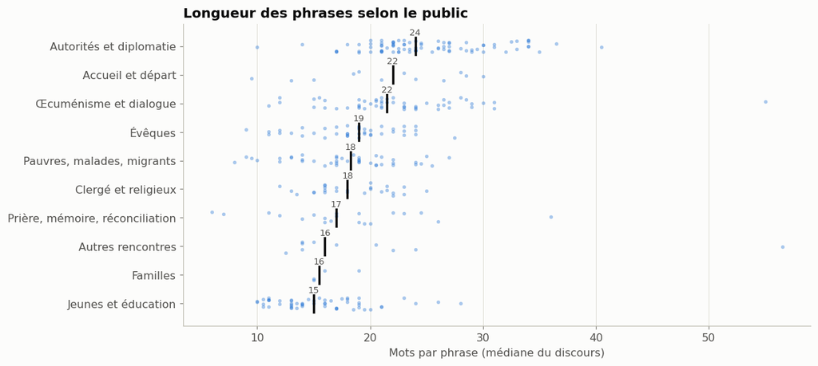

```python
FIN = re.compile(r"(?<=[.!?])\s+(?=[\"“A-Z])")
df["mots_par_phrase"] = df["text"].map(lambda t: np.median([len(ac.mots(p)) for p in FIN.split(t) if p.strip()] or [np.nan]))
pubs_tous = [p for p in ac.ORDRE_PUBLICS if (df["public"] == p).any()]
med = df.groupby("public", observed=True)["mots_par_phrase"].median().reindex(pubs_tous)
ordre = med.sort_values().index
fig, ax = plt.subplots(figsize=(11, 5))
rng = np.random.default_rng(1)
for i, p in enumerate(ordre):
    v = df.loc[df["public"].eq(p), "mots_par_phrase"].dropna()
    ax.scatter(v, i + rng.uniform(-.22, .22, len(v)), s=12, color=ac.SERIES[0], alpha=.4, linewidths=0)
    ax.plot([med[p]] * 2, [i - .3, i + .3], color=ac.ENCRE, linewidth=2.2)
    ax.text(med[p], i + .38, f"{med[p]:.0f}", ha="center", fontsize=8.5, color=ac.ENCRE_2)
ax.set_yticks(range(len(ordre)), ordre)
ax.grid(axis="y", visible=False)
ax.set(xlabel="Mots par phrase (médiane du discours)", title="Longueur des phrases selon le public")
fig.tight_layout(); plt.show()
```